# Practical training Rmarkdown

Willem Stolte

February 25, 2016

## Start a new Rmarkdown document

- In Rstudio, choose from file menu: New File / R Markdown…
- Determine what kind of document you want it to be
  - for this training, choose “html” Note that you can also choose a presentation, which changes the choices of the formats that it can handle
- The document opens with some standard, functional, content to get going
- Note that the document contains both “normal” text (with Markdown formatting) combined with ‘chunks’ of R code (the grey pieces)
- Try and run the document by pressing the “Knit html” button just above the document in Rstudio
  - an html document appears in which the Rmarkdown + R code is combined to a single document.

Add new data Now, we are going to use data from an online source. We will use data from the Marine Projects database.

Code can be inserted by “insert a new code chunk” button (green c) or by ctrl-alt-i

Make a document that reads data, and uses the data for a time plot.

```r
## first look which layers there are in the wfs
## (can also interactively be done in QGIS)
library(gdalUtils)
library(rgdal)
dsn <- "http://marineprojects.openearth.nl/geoserver/mep-nsw/ows?service=WFS&request=GetCapabilities"
dsn <- "http://marineprojects.openearth.nl/geoserver/ows?service=WFS&request=GetCapabilities"
ogrinfo(dsn, so=TRUE)
```

```
##  [1] "INFO: Open of `http://marineprojects.openearth.nl/geoserver/ows?service=WFS&request=GetCapabilities'"
##  [2] "      using driver `WFS' successful."
##  [3] "1: inspire_marine:Inspire_Marine"
##  [4] "2: shwoz:shwoz"
##  [5] "3: RijMaMo:Zoutgehalte bij Hoek van Holland"
##  [6] "4: shwoz:kleinemantelmeeuw (Point)"
##  [7] "5: rwsbenthos:meetobject"
##  [8] "6: mep-nsw:mep-nsw_bentcom"
##  [9] "7: ihm_viewer:mep-nsw_benthos"
## [10] "8: mep-nsw:mep-nsw_bivalves"
## [11] "9: mep-nsw:mep-nsw_didson"
## [12] "10: mep-nsw:mep-nsw_dvis"
## [13] "11: mep-nsw:mep-nsw_gillnet"
## [14] "12: mep-nsw:mep-nsw_macrobenthos"
## [15] "13: mep-nsw:mep-nsw_pvis"
## [16] "14: ihm_viewer:mep-nsw_vis"
## [17] "15: rwsbenthos:meting"
## [18] "16: rwsbenthos:meting_1992"
## [19] "17: rwsbenthos:meting_1993"
## [20] "18: rwsbenthos:monster"
## [21] "19: ihm_viewer:shwoz_vliegroute_mantelmeeuw"
## [22] "20: ihm_viewer:shwoz_vogels"
## [23] "21: ihm_viewer:shwoz_zeezoogdieren"
```

```r
## define url of WFS service, where data are served as csv file:
url <- "http://marineprojects.openearth.nl/geoserver/mep-nsw/ows?service=WFS&version=1.0.0&request=GetFeature&typeName=mep-nsw:mep-nsw_bivalves&maxFeatures=50&outputFormat=csv"
## read data as csv (strings are read as character type, not as factors)
bivalves <- read.csv(url, stringsAsFactors = F)
```

Observe that these are only the first 50 records. This is perfect for testing.

```r
##Look at the structure of the data set in the environment pane, or by running:
str(bivalves)
```

```
## 'data.frame':    50 obs. of  30 variables:
##  $ FID                         : chr  "mep-nsw_bivalves.fid-336b7e76_1533271048f_-451b" "mep-nsw_bivalves.fid-336b7e76_1533271048f_-451a" "mep-nsw_bivalves.fid-336b7e76_1533271048f_-4519" "mep-nsw_bivalves.fid-336b7e76_1533271048f_-4518" ...
##  $ Meetpunt.identificatie      : chr  "Windmolenpark Egmond aan Zee" "Windmolenpark Egmond aan Zee" "Windmolenpark Egmond aan Zee" "Windmolenpark Egmond aan Zee" ...
##  $ Metingomschrijving          : chr  "R4-84" "R3-60" "R3-55" "R3-51" ...
##  $ GeometriePunt.x             : num  4.31 4.51 4.49 4.49 4.4 ...
##  $ GeometriePunt.y             : num  52.6 52.7 52.7 52.7 52.7 ...
##  $ Geometrie                   : chr  "POINT (4.30577 52.55672)" "POINT (4.50608 52.65967)" "POINT (4.49022 52.65822)" "POINT (4.4898 52.66998)" ...
##  $ Referentiehorizontaal.code  : chr  "EPSG:4258" "EPSG:4258" "EPSG:4258" "EPSG:4258" ...
##  $ Monster.identificatie       : int  319 314 310 298 291 274 258 328 324 301 ...
##  $ compartiment.code           : chr  "OE" "OE" "OE" "OE" ...
##  $ orgaan.code                 : logi  NA NA NA NA NA NA ...
##  $ organisme.naam              : chr  "Abra alba" "Abra alba" "Abra alba" "Abra alba" ...
##  $ begindiepte_m               : num  18.6 22 20.6 20.7 22.6 ...
##  $ einddiepte_m                : num  18.6 22 20.6 20.7 22.6 ...
##  $ bemonsteringsmethode.code   : logi  NA NA NA NA NA NA ...
```

[output cut: 16 more lines]

```r
## Date and time are characters at this moment. They can be converted to date and time object by combining them in a new column 'datetime':
bivalves$datetime <- paste(bivalves$Begindatum, bivalves$Begintijd)
## and convert to POSIXct format
bivalves$datetime <- as.POSIXct(bivalves$datetime, format = "%Y-%m-%d %H:%M")
```

First, we plot locations, longitude and latitude fields are used. Using Base functionality

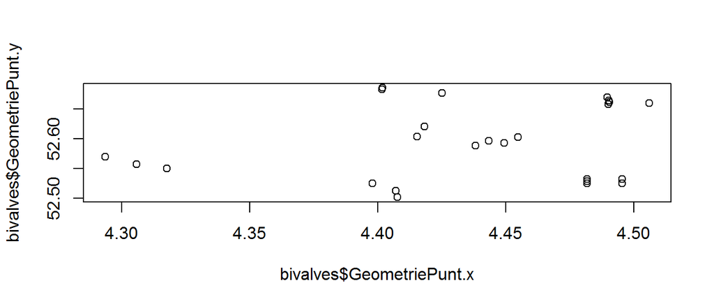

```r
plot(bivalves$GeometriePunt.x, bivalves$GeometriePunt.y)
```

Or using the ggplot package

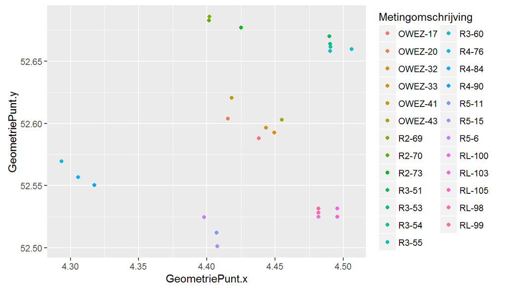

```r
require(ggplot2)
p <- ggplot(bivalves, aes(GeometriePunt.x, GeometriePunt.y))
p + geom_point(aes(color = Metingomschrijving))
```

Or using an interactive map

```r
require(leaflet)
leaflet() %>%
  addTiles(group = "OSM (default)") %>%
  addCircleMarkers(data=bivalves,
                   lng = bivalves$GeometriePunt.x,
                   lat = bivalves$GeometriePunt.y,
                   popup = sprintf(as.character(bivalves$Metingomschrijving))
                   # clusterOptions = markerClusterOptions()
                   )
```

[interactive chart not shown]